# Week 5 Written Homework

Chris Moroney

2020-10-18

```r
library(tidyverse)
library(openintro)
library(mdsr)
library(Lahman)
library(nycflights13)
```

### WMD Chapter 6 and 7 Reflection

Chapter 6 is primarily about O’Neil telling stories of how software caused errors and mistakes in the hiring process for companies, which was Kronos and a British Hospital. O’Neil emphasizes that one of the most problematic aspects of using software for the hiring process in companies is that they don’t provide good feedback from the feedback loop (page 112), and how the system ends up being more efficient instead of providing fairness to the hiring process (page 116). O’Neil finishes this chapter by mentioning how WMD’s can be “pernicious” or harmful, but also can provide help and assistance, depending on our objective altogether. Chapter 7 is on a similar topic as Chpater 6 in software amongst companies, but rather has more of an emphasis on what software does inside of a company. Such examples of how software was used inside of companies was for rating staff performance. The results that came were often times very negative, which O’Neil also describes as “poisonous prejudices” against employees (page 123). If there was one question that I would ask O’Neil, it would be “do the companies have a certain expectation of the software when used in the companies?” Given that software is software, and often times used for automation, I was just wondering if there was too much of an expectation for software to provide both positive and negative feedback within companies.

I find it interesting that since Chapter 5, O’Neil has really hammered hard how software has really caused negative reforms in universities and companies. I feel like reading this really hits home for me because as I am studying computer science, I feel I am responsible for what has happened both before in companies and universities, as well as what will happen in the future. I feel some anxiety because I believe that O’Neil has plenty of evidence to show that software has had a very negative impact on universities and companies, particularly when evaluating the performance of these institutions. I’m not sure entirely what specific software was used, such as a particular model of if there was Machine Learning or AI used, but I truly believe that software is continually evolving and can prove O’Neil wrong in the long term. I imagine that some company will be able to come up with some AI model to improve the situations created in these universities and companies. However, even if there isn’t “improvement”, if I decide to work in this type of software or AI field, I need to make sure that the product that I develop does not result in causing more harm to these institutions. That is perhaps the worst contribution that one can deliver, and would only reinforce what O’Neil is saying about software in companies and universities. We cannot allow software to continue to be “poisonous prejudices” against students, employees, or managers in particular institutions, otherwise we may see software dying in today’s world, which can cause a major economic collapse altogether.

### Exercise 4.1

1. mean(variable)
2. mutate(dataset, newvariable=variable1/variable2)
3. arrange(desc(variable))
4. filter(criteria)
5. select(A, X)

### Exercise 4.2

```r
flights %>%
  group_by(month) %>%
  summarize(cancelled_flight_ratios=sum(is.na(arr_delay))/sum(n())) %>%
  arrange(desc(cancelled_flight_ratios))
```

```
## # A tibble: 12 x 2
##    month cancelled_flight_ratios
##    <int>                   <dbl>
##  1     2                 0.0537
##  2     6                 0.0414
##  3    12                 0.0396
##  4     7                 0.0385
##  5     3                 0.0323
##  6     4                 0.0270
##  7     5                 0.0232
##  8     1                 0.0224
##  9     9                 0.0205
## 10     8                 0.0195
## 11    11                 0.0109
## 12    10                 0.00938
```

### Exercise 4.8

```r
Teams <- mutate(Teams,
                BA = H / AB,
                SLG = ((H-(X2B+X3B+HR)) + (2*X2B) + (3*X3B) + (4*HR))/(AB))
```

### Exercise 4.9

In general, in more recent years, it looks like the American League has a slightly higher SLG percentage than in the NL. However before around 1980-1990, it seems like the leagues were more even in terms of SLG percentage. One possible reason for the difference in SLG percentage is because in the AL, pitchers exclusively pitch, whereas in the NL, pitchers have to pitch and hit in the same game. The extra hitter in the AL is known as a Designated Hitter (DH), and this player only bats. Pitchers are typically not very strong hitters, which means that pitchers are much less likely to gain bases by hitting. Thus, the difference in lineups between the AL teams and NL teams may favor the AL teams because the NL teams have a batter that is a pitcher, whereas the AL teams have a hitting specialist, which is more likely to earn bases.

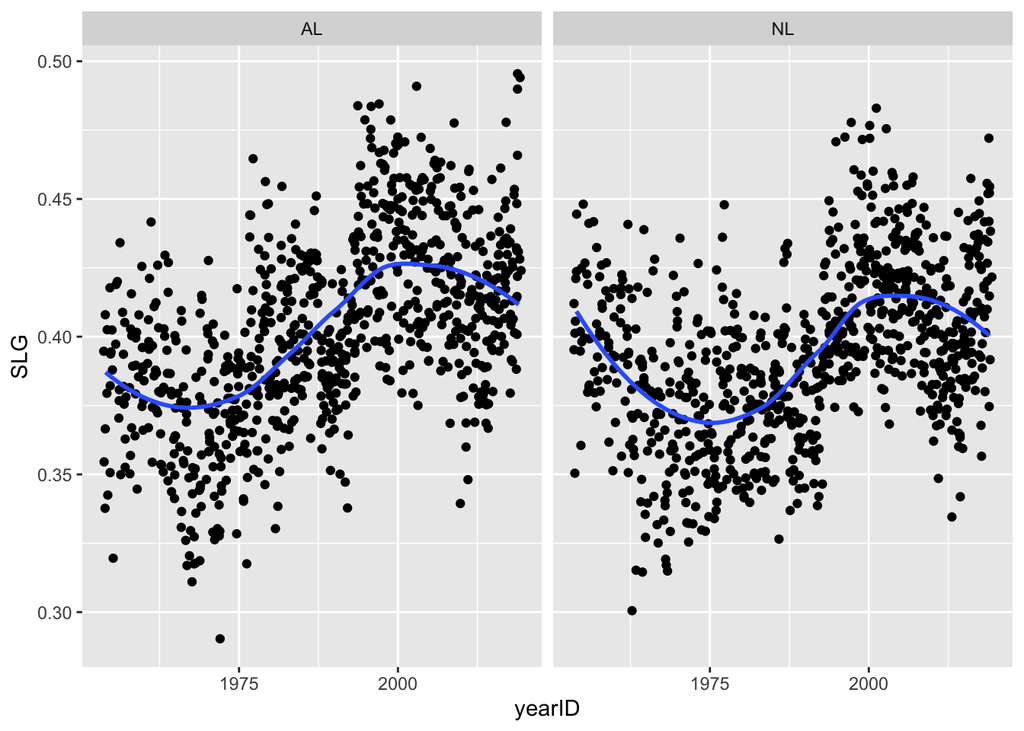

```r
since1954 <- Teams %>%
  filter(yearID >= 1954)

ggplot(data=since1954, mapping=aes(x=yearID, y=SLG))+
  geom_jitter() +
  geom_smooth(se = FALSE) +
  facet_wrap(~ lgID)
```

### Exercise 4.10

These are the top 15 teams since 1969 with the highest SLG percentages.

```r
Teams %>%
  filter(yearID >= 1969) %>%
  arrange(desc(SLG)) %>%
  select(yearID, name, SLG) %>%
  head(15)
```

```
##    yearID              name       SLG
## 1    2019    Houston Astros 0.4954570
## 2    2019   Minnesota Twins 0.4940684
## 3    2003    Boston Red Sox 0.4908996
## 4    2019  New York Yankees 0.4898800
## 5    1997  Seattle Mariners 0.4845030
## 6    1994 Cleveland Indians 0.4838389
## 7    1996  Seattle Mariners 0.4835921
## 8    2001  Colorado Rockies 0.4829525
## 9    1995 Cleveland Indians 0.4787192
## 10   1999     Texas Rangers 0.4786763
## 11   2017    Houston Astros 0.4778114
## 12   1997  Colorado Rockies 0.4777798
## 13   2009  New York Yankees 0.4775618
## 14   2000    Houston Astros 0.4766607
## 15   2003    Atlanta Braves 0.4754850
```

### Exercise 4.14

Walter Johnson, Greg Maddux, Roger Clemens, Steve Carlton, Nolan Ryan, Don Sutton, Phil Niekro, Gaylord Perry, Tom Seaver, and Randy Johnson all have at least 300 career wins and 3000 career strikeouts.

```r
Pitching %>%
  group_by(playerID) %>%
  summarize(careerWins = sum(W), careerSO = sum(SO)) %>%
  filter(careerWins >= 300 & careerSO >= 3000) %>%
  left_join(People, by = c("playerID" = "playerID")) %>%
  select(nameFirst, nameLast, careerWins, careerSO) %>%
  arrange(desc(careerWins, careerSO))
```

```
## # A tibble: 10 x 4
##    nameFirst nameLast careerWins careerSO
##    <chr>     <chr>         <int>    <int>
##  1 Walter    Johnson         417     3509
##  2 Greg      Maddux          355     3371
##  3 Roger     Clemens         354     4672
##  4 Steve     Carlton         329     4136
##  5 Nolan     Ryan            324     5714
##  6 Don       Sutton          324     3574
##  7 Phil      Niekro          318     3342
##  8 Gaylord   Perry           314     3534
##  9 Tom       Seaver          311     3640
## 10 Randy     Johnson         303     4875
```

### Exercise 4.15

Out of all the players to have hit 50 Home Runs in a season in MLB history, Pete Alonso (New York Mets) had the lowest batting average at 0.259.

```r
Batting %>%
  mutate(Batting,
         BA = H / AB) %>%
  filter(HR >= 50) %>%
  left_join(People, by = c("playerID" = "playerID")) %>%
  select(nameFirst, nameLast, yearID, HR, BA) %>%
  arrange(BA)
```

```
##    nameFirst  nameLast yearID HR        BA
## 1       Pete    Alonso   2019 53 0.2596315
## 2       Jose  Bautista   2010 54 0.2601054
## 3     Andruw     Jones   2005 51 0.2627986
## 4      Roger     Maris   1961 61 0.2694915
## 5       Greg    Vaughn   1998 50 0.2722513
## 6      Cecil   Fielder   1990 51 0.2774869
## 7       Mark   McGwire   1999 65 0.2783109
## 8  Giancarlo   Stanton   2017 59 0.2814070
## 9      Aaron     Judge   2017 52 0.2841328
## 10       Ken   Griffey   1998 56 0.2843602
## 11     Chris     Davis   2013 53 0.2859589
## 12     David     Ortiz   2006 54 0.2867384
## 13    Prince   Fielder   2007 50 0.2879581
## 14     Sammy      Sosa   1999 63 0.2880000
```

[output cut: 31 more lines]

### Exercise 4.17

In general, what I observe is that zip codes with a higher median score usually have a larger number of inspections than zip codes with lower median scores. However, this is not a very accurate generalization as I can observe this pattern in a very general sense. Nearer to the bottom of the list (lower median score), more zip codes have around 500 or so inspections, whereas at the top of the list, there are usually thousands of inspections, but this pattern is not consistent throughout the entire data set. Generally speaking, however, I can observe that a higher median score generally means that there were more inspections in general.

```r
Violations %>%
  filter(!is.na(score)) %>%
  group_by(zipcode) %>%
  summarize(median_score = median(score), num_inspections = sum(n())) %>%
  filter(num_inspections >= 50) %>%
  select(zipcode, median_score, num_inspections) %>%
  arrange(desc(median_score))
```

```
## # A tibble: 188 x 3
##    zipcode median_score num_inspections
##      <int>        <dbl>           <int>
##  1   11697           21              69
##  2   10310           20             898
##  3   11220           20            6476
##  4   11428           20             887
##  5   10013           19            9567
##  6   10025           19            4723
##  7   10026           19            1468
##  8   10280           19             170
##  9   10304           19             895
## 10   11204           19            2512
## # … with 178 more rows
```